# RedWine Dataset Exploratory Data Analysis

The main motto of this report is to explore and find out the factors which influence the quality ratings of Wine. This in turn can help the company which produces wine, to improve the qualities on which it can work on to give a better quality product.

This is going to be done with 1599 entries and 12 Factors which might have an influence on the Quality Ratings.

```
##   fixed.acidity volatile.acidity citric.acid residual.sugar chlorides
## 1           7.4             0.70        0.00            1.9     0.076
## 2           7.8             0.88        0.00            2.6     0.098
## 3           7.8             0.76        0.04            2.3     0.092
## 4          11.2             0.28        0.56            1.9     0.075
## 5           7.4             0.70        0.00            1.9     0.076
## 6           7.4             0.66        0.00            1.8     0.075
##   free.sulfur.dioxide total.sulfur.dioxide density   pH sulphates alcohol
## 1                  11                   34  0.9978 3.51      0.56     9.4
## 2                  25                   67  0.9968 3.20      0.68     9.8
## 3                  15                   54  0.9970 3.26      0.65     9.8
## 4                  17                   60  0.9980 3.16      0.58     9.8
## 5                  11                   34  0.9978 3.51      0.56     9.4
## 6                  13                   40  0.9978 3.51      0.56     9.4
##   quality
## 1       5
## 2       5
## 3       5
## 4       6
## 5       5
## 6       5
```

Transforming Quality from an Integer to a Factor

Creating a new Factored Variable called ‘Rating’

**Guiding Question: Which factors influence the Quality Ratings of Red Wine?**

We need to check that.

## Univariant Plots Section

Our data set consists of 13 Variables with almost 1600 entries.

**Fixed Acidity**

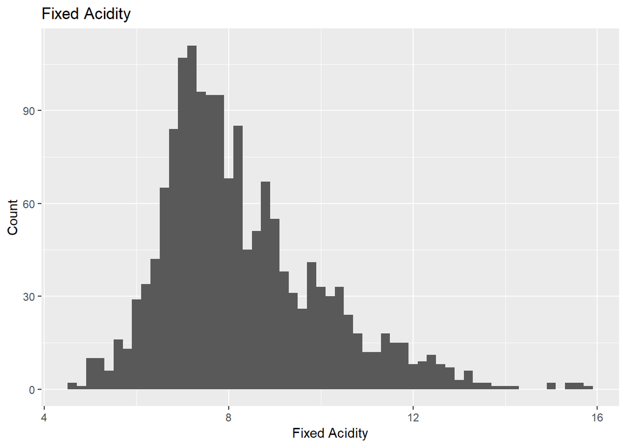

```
##    Min. 1st Qu.  Median    Mean 3rd Qu.    Max.
##    4.60    7.10    7.90    8.32    9.20   15.90
```

We can see that the fixed acidity graph is skewed to the right. The mean is 8.32 and the median is 7.9.

**Citric Acid**

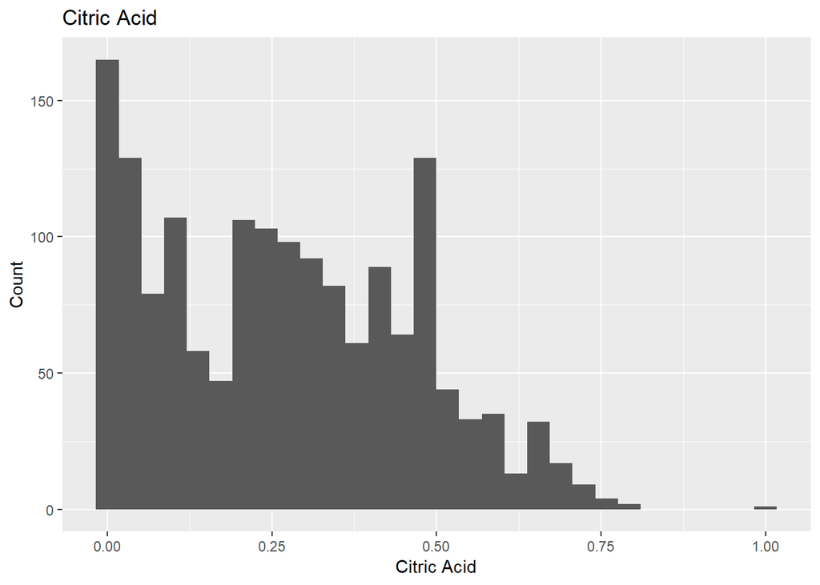

```
##    Min. 1st Qu.  Median    Mean 3rd Qu.    Max.
##   0.000   0.090   0.260   0.271   0.420   1.000
```

**Residual Sugar**

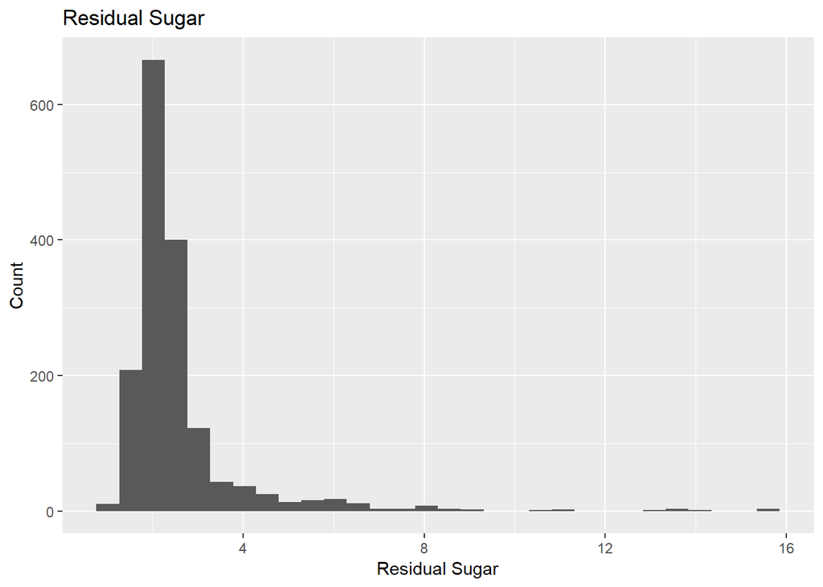

```
##    Min. 1st Qu.  Median    Mean 3rd Qu.    Max.
##   0.900   1.900   2.200   2.539   2.600  15.500
```

**Volatile Acidity**

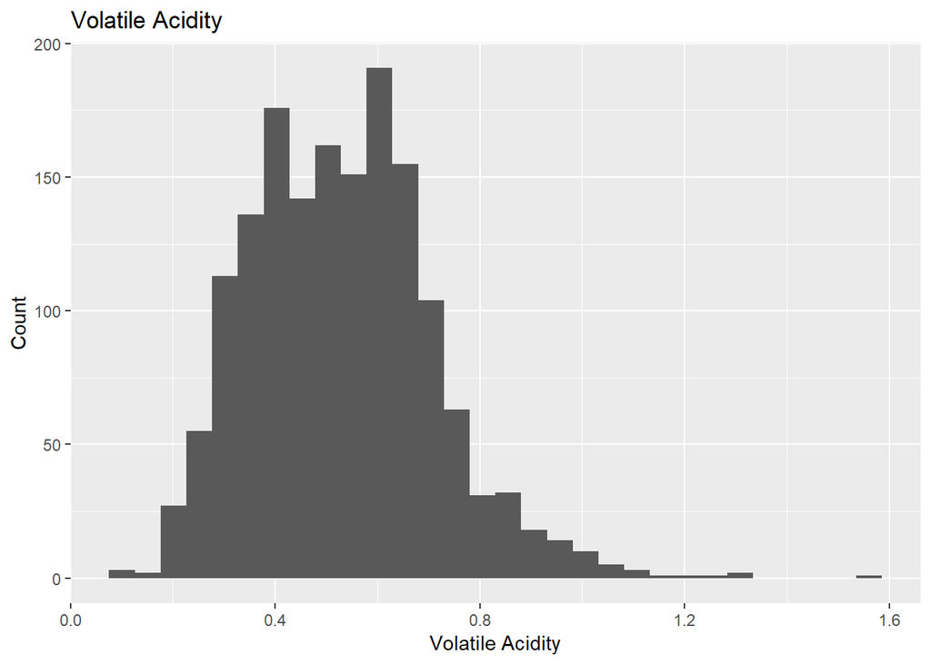

```
##    Min. 1st Qu.  Median    Mean 3rd Qu.    Max.
##  0.1200  0.3900  0.5200  0.5278  0.6400  1.5800
```

**Chlorides**

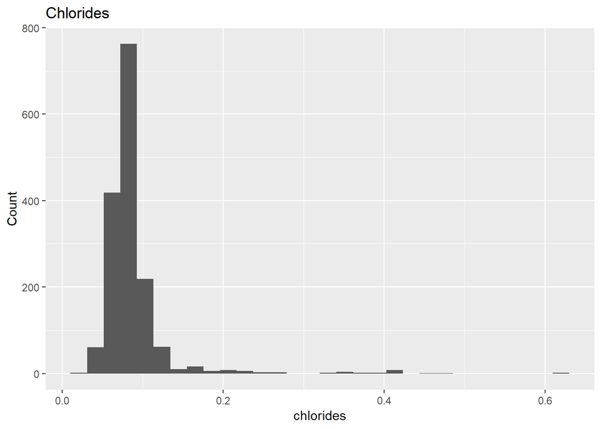

```
##    Min. 1st Qu.  Median    Mean 3rd Qu.    Max.
## 0.01200 0.07000 0.07900 0.08747 0.09000 0.61100
```

**Free Sulfur Dioxide**

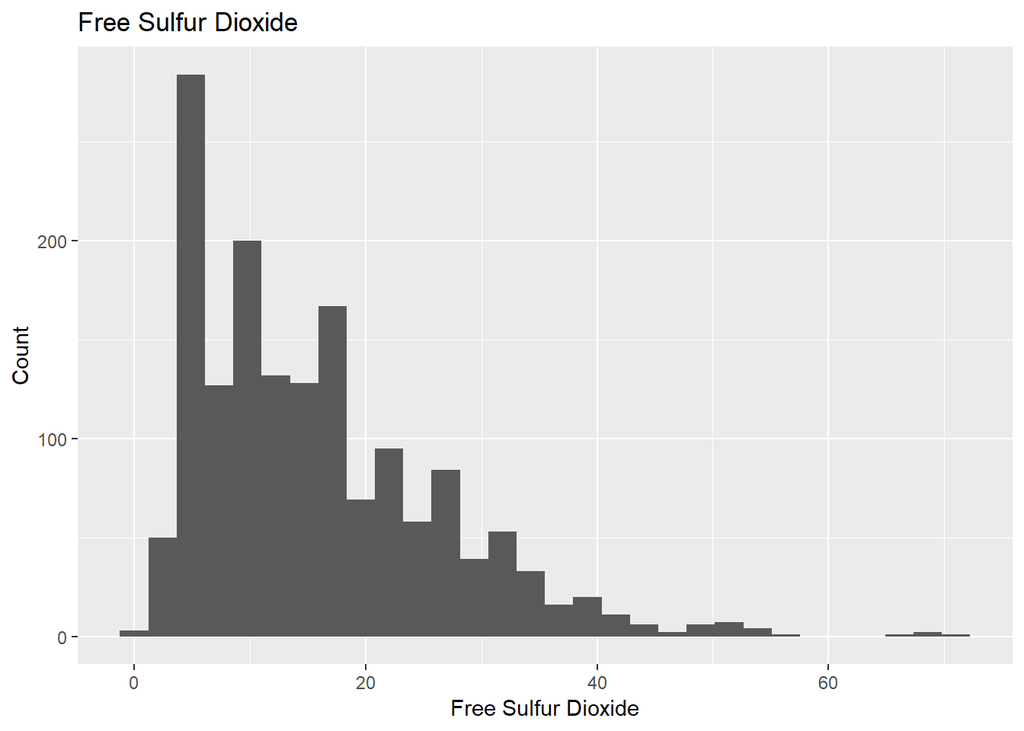

```
##    Min. 1st Qu.  Median    Mean 3rd Qu.    Max.
##    1.00    7.00   14.00   15.87   21.00   72.00
```

This graph is skewed to the right. The mean is 15.87 and the median is 14.00.

**Total Sulfur dioxide**

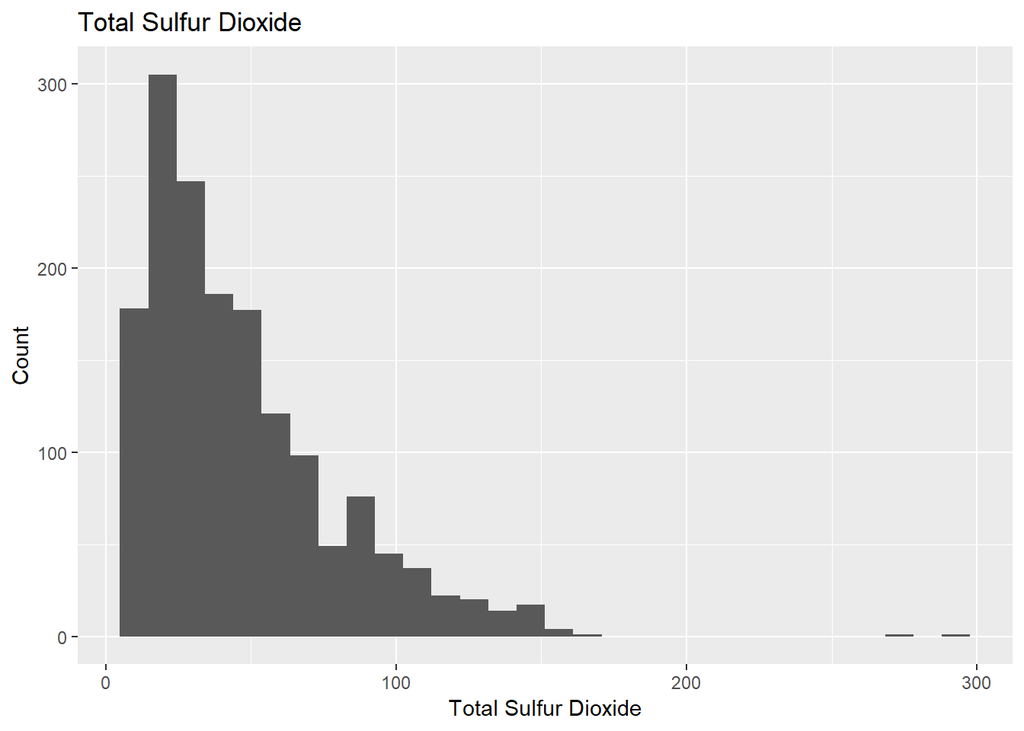

```
##    Min. 1st Qu.  Median    Mean 3rd Qu.    Max.
##    6.00   22.00   38.00   46.47   62.00  289.00
```

This graph is skewed to the right. The mean is 46.47 and the median is 38.00

**Density**

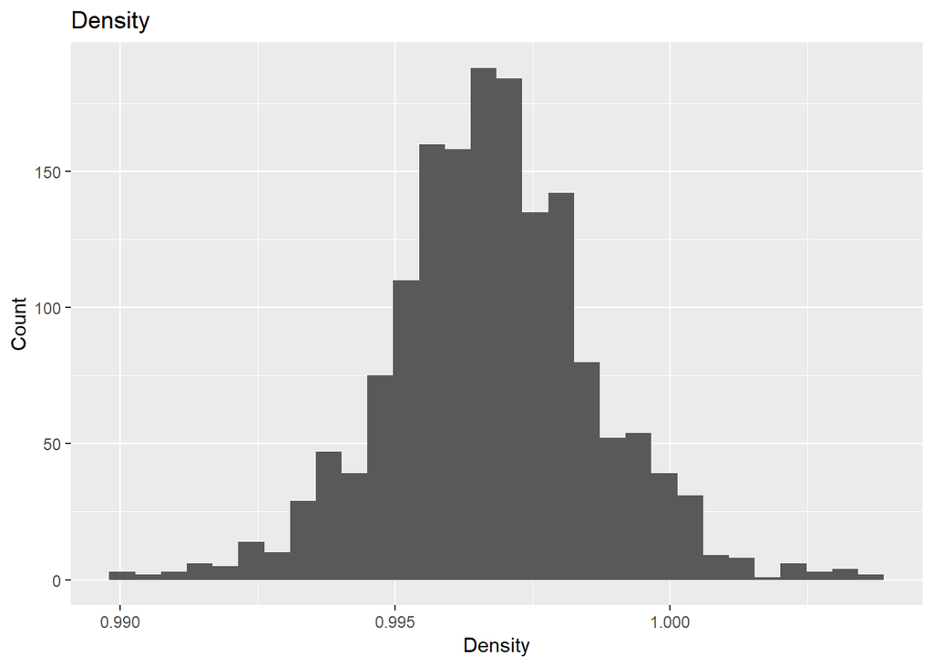

```
##    Min. 1st Qu.  Median    Mean 3rd Qu.    Max.
##  0.9901  0.9956  0.9968  0.9967  0.9978  1.0037
```

This graph is normally distributed. The mean is 0.9967 and the median is 0.9968

**pH**

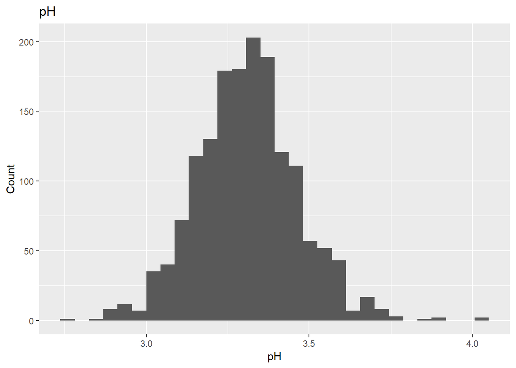

```
##    Min. 1st Qu.  Median    Mean 3rd Qu.    Max.
##   2.740   3.210   3.310   3.311   3.400   4.010
```

We can see that this graph is normally distributed. The mean is 3.311 an the median is 3.31

**Sulphates**

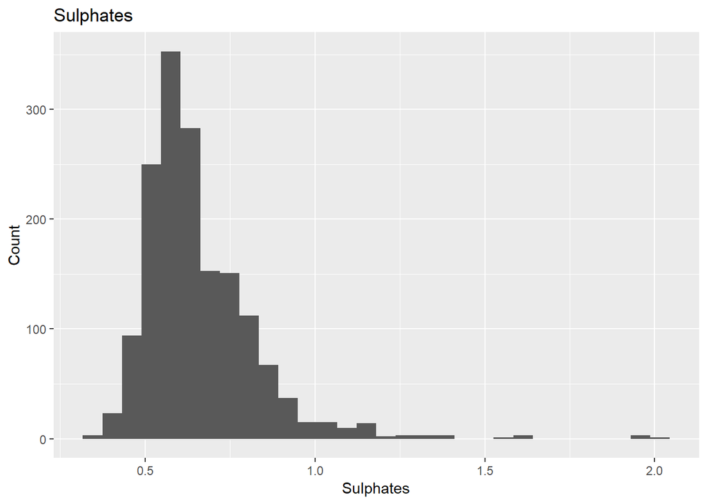

```
##    Min. 1st Qu.  Median    Mean 3rd Qu.    Max.
##  0.3300  0.5500  0.6200  0.6581  0.7300  2.0000
```

We can see that this graph is positively skewed. The mean is 0.65 and the median is 0.62.

**Alcohol**

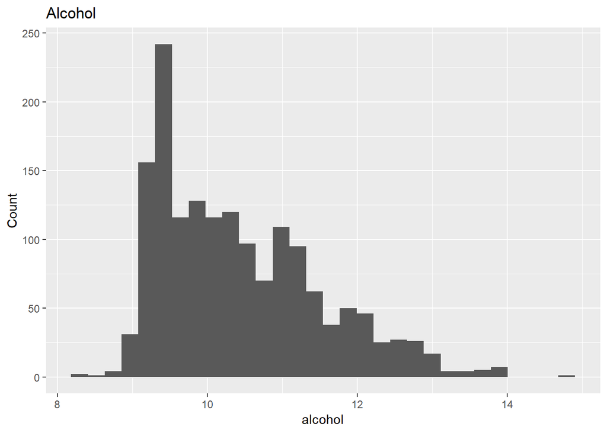

```
##    Min. 1st Qu.  Median    Mean 3rd Qu.    Max.
##    8.40    9.50   10.20   10.42   11.10   14.90
```

The graph is positively skewed. The mean is 10.42 and the median is 10.20.

**Quality**

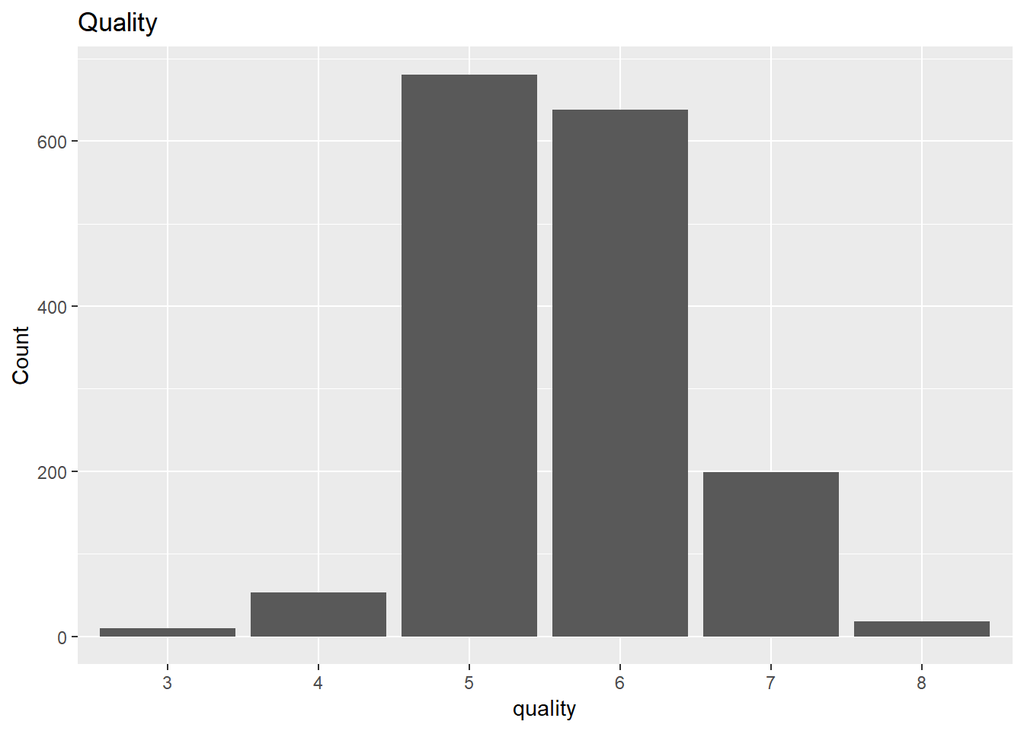

```
##   3   4   5   6   7   8
##  10  53 681 638 199  18
```

**Quality Rating**

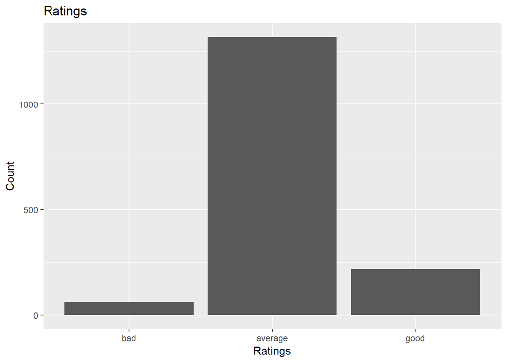

[output not shown]

## Univariant Analysis Section:

**What is the structure of the dataset?**

There are about 1600 observations made about red wines and the factors which have been taken into consideration include alcohol content, pH, residual sugars, volatile acidity, fixed acidity, free sulfurdioxide, total sulfur dioxide, density, sulphates, chlorides, citric acid. And the main factor which will be focused on Quality Ratings and how it relates to the other variables when directly plotted with them.

The other observations made are as follows:

**What are the main features of interest in the dataset?**

The main features of the dataset is Quality ratings. The Features which might have an influence on the Quality ratings are the alcohol content, pH, density, sugar content and Chorides. If we plot them directly against Quality ratings we can know the relation for sure.

**Any new variables created?**

A new variable, rating, has been created. It helps in grouping the Quality rating into three categories of bad, average and good.

I feel this will make it easier to conclude the quality of wine just on looking at the rating, rather than looking at numbers and deciding.

**Were there any outliers in the dataset? If so, how?**

This is the same case with other variables such as Sulphates, Chlorides and Total Sulfur dioxide.

It is very clear that many observations have the Citric Acid content as zero. This maybe due to citric acid data entry could have been either missed or omitted or actual value being zero.

## Bivariant Plots Section

The Quality Ratings will be compared to different variables since it is the Ratings which determine if the Wine is good or not. If the wine is likable or not. This can be used by the production company to implement and improve their standards.

First up, we compare one of the most important features which might determine the Ratings of the Wine. The Alcohol Content. So we plot a scatter plot as follows.

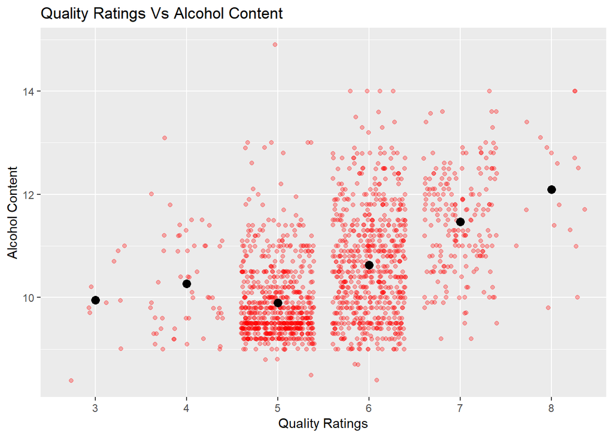

We can note from the above Quality Vs Alcohol Rating that we have an increase in the Quality Ratings of the Wine with the increase in the alcohol content in it. We can observe a few ##outliers as well in the data. For example, the highest alcohol content, near 15 only has a rating of just above 5.

Next we will see how the sugar level in the alcohol will determine the Quality Ratings of the Wine.

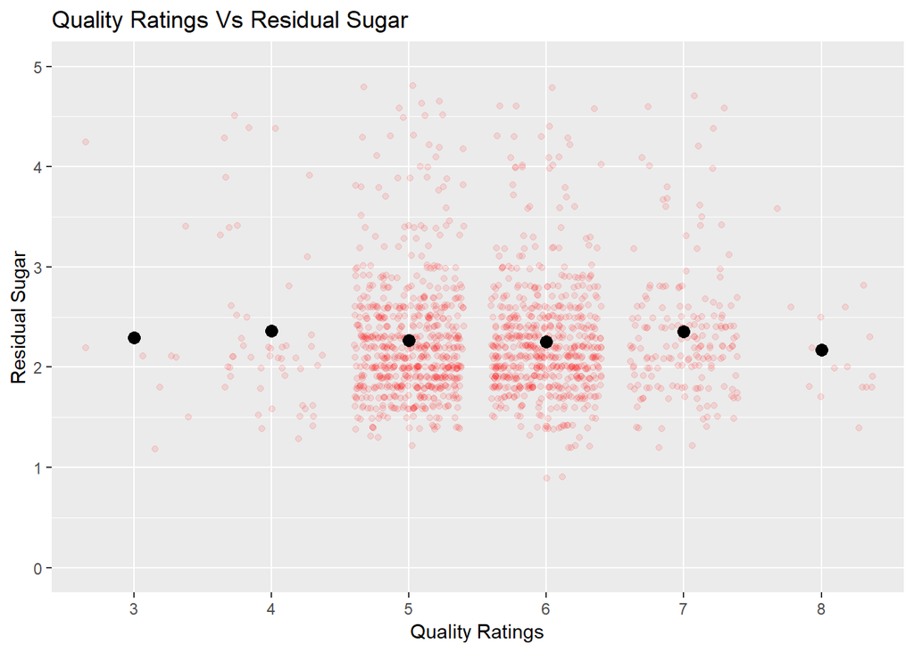

Surprisingly the Sugar Content remains constant through all the Quality Rating,

This can be infered as Sugar Content not having an influence on the Quality Ratings.

Next plot is between Quality and pH Content.

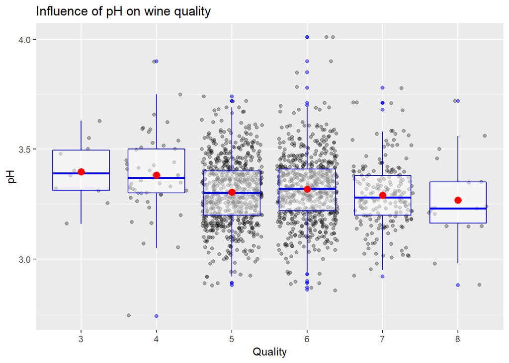

As we see the plot, we can observe the there is a slight drop in pH as the quality increases. Also, we find that the median of the box plots coincides with the mean produced with the help of stat summary.

Plot between Density and The Quality Ratings

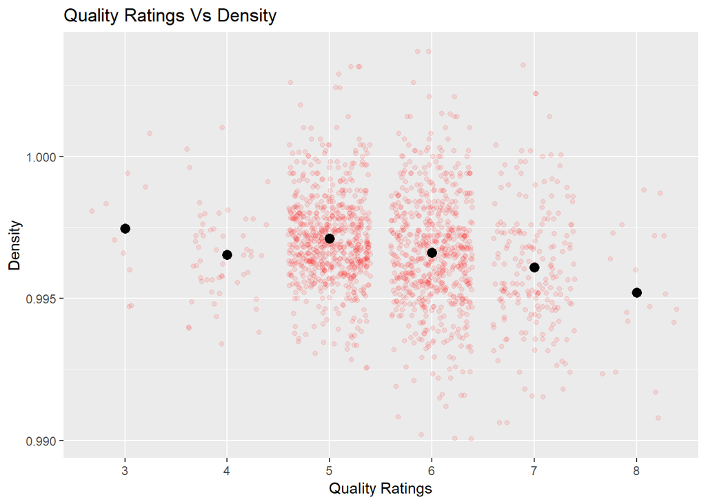

We can see that the Quality Ratings are increasing with the decrease in Density.

Hence we can conclude that Lesser the density, better the Wine.

Plot between Fixed Acidity and pH.

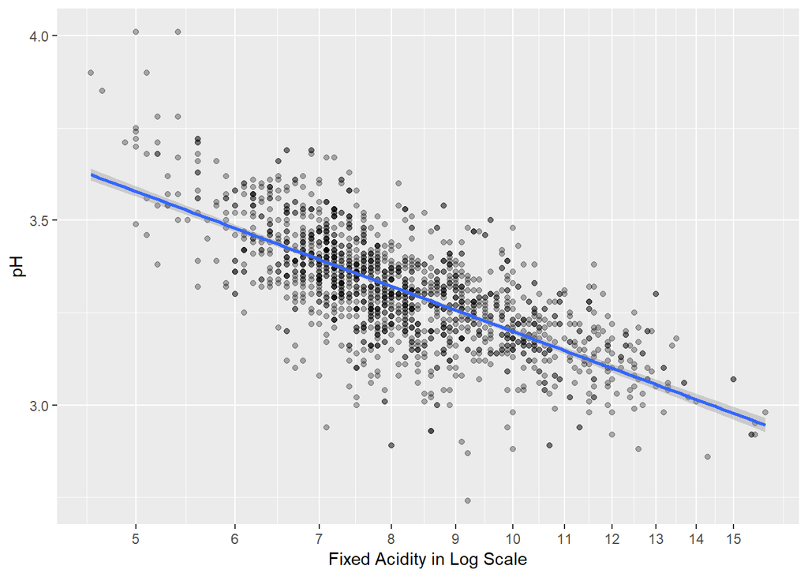

In this plot we can notice a clear negative relation between Fixed Acidity in log scale and pH. But the pH has a negative relation with the Quality Ratings. Hence, better the fixed acidity, better the quality of wine.

Next is the plot between volatile acidity and the alcohol content.

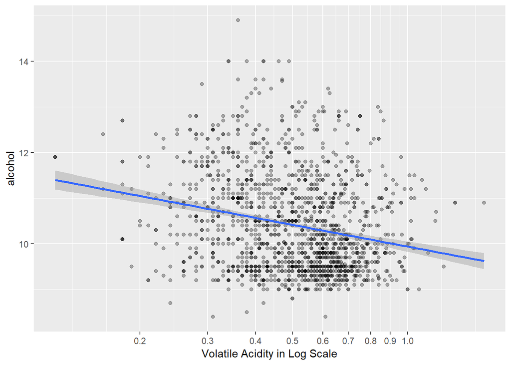

We can observe a downward trend. But it is not as clear as the plot obtained for Fixed Acidity Vs pH. Since alcohol has a positive relation with the Quality ratings. Hence the Volatile acid on a log scale has a negative relation with Quality Ratings.

## Bivariant Analysis Section

**What were the relationships observed in the analysis of a variable and how it affects the Quality Analysis?**

I have plotted four variables against the Quality Ratings. They are as follows.

1. The first one is Quality Ratings Vs Alcohol Content. We can clearly observe a positive relation between Quality ratings and Alcohol Content, that there is an increase in Quality Ratings as there is an increase in the Alcohol content.
2. The Second Graph is between Quality Ratings and Residual Sugars. Surprisingly, there is no change in the mean sugar level even with the increase in quality ratings. So the conclusion is that the Quality ratings of the wine do no depend on the Sugar content in the wine.
3. The Third Graph is between Quality Ratings and pH. In this case, we can see a slight decrease in pH level as the Quality Ratings increase. Hence we can conclude that the decrease in pH can result in better quality of wine produced.
4. The Fourth Graph is between Quality Ratings and Density. Similar to pH, there is a downward trend in density as the Quality Ratings increase.

**What were the other relationship observed other than the main feature of interest That is the Quality Analysis?**

There were two other relations made and conclusions were drawn from the graphs that were plotted

1. The first graph plotted was between Fixed Acidity on log scale and pH. This graph showed a clear negative relationship between Fixed Acidity and pH. That is, with the increase in pH there was a decrease in Fixed Acidity.
2. The second graph plotted was between Volatility Acid and Alcohol content. This graph does not have a representation as clear as the Fixed Acidity and pH graph. But we can observe that here too there is a negative relation between Volatility acid and alcohol content. This in turn also tells us that there is negative relation between Volatility acid and the Quality of wine that is produced.

**Where there any unexpected anomalies in the relations obtained?**

I was surprised to see no relationship between the amount of sugars, ie) Residual sugars and the Quality ratings. There was an expectation to see a relationship but there wasn’t one.

## Multivariant Plots Section

Now we will investige the quality ratings of wine and how the other factors affect it taking more than two variables into consideration.

The first plot is with Factors we saw affecting the quality ratings signifantly namely alcohol content and pH value.

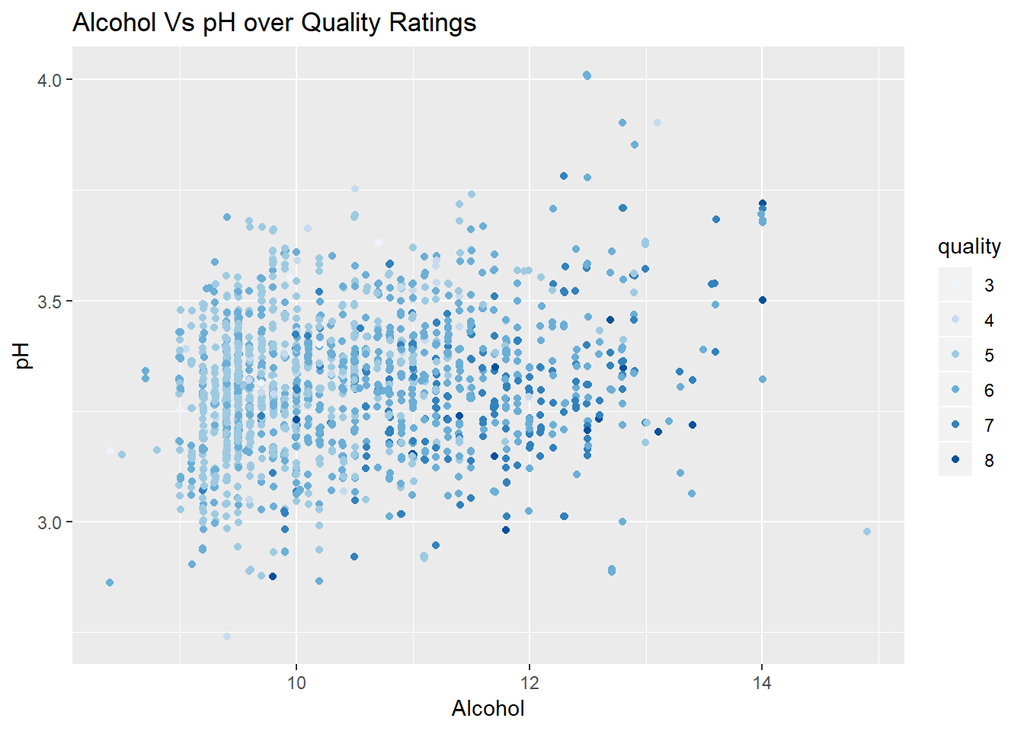

It is reassuring to see that our previous conclusion has been proved true here. The alcohol does indeed have a positive relation with the Quality ratings. There are more dark blue points to the right of the graph than to the left.

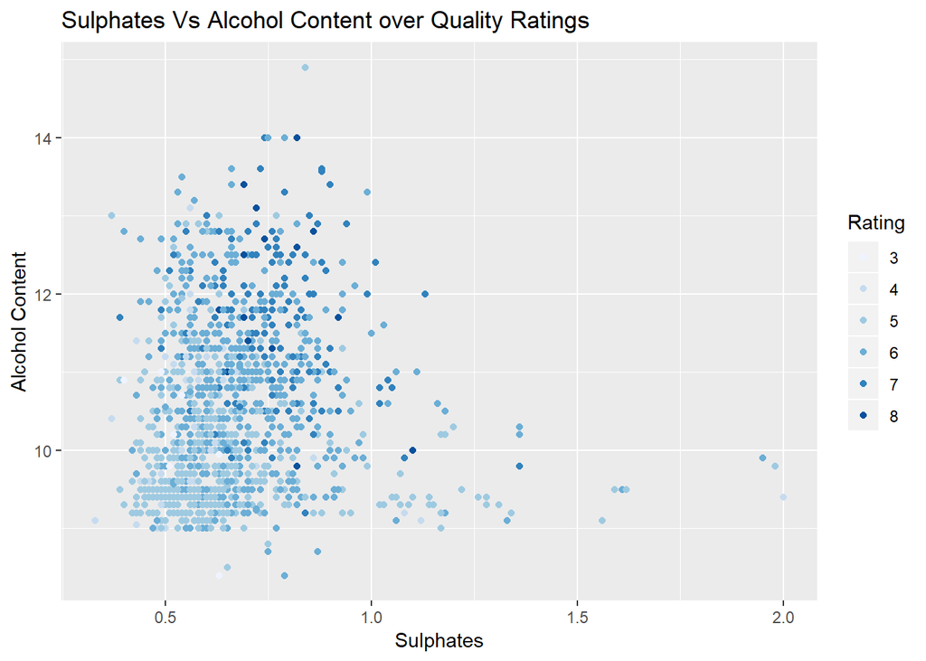

It looks like the quality of wines increases with the increase in alcohol content and more sulphate content.

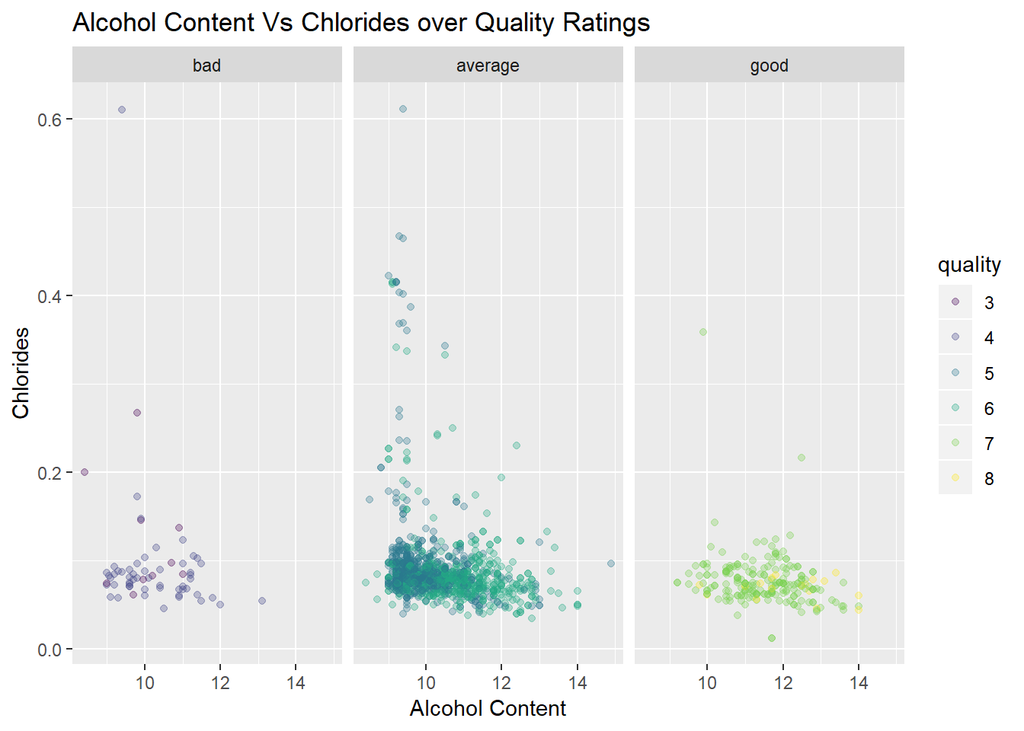

It is clear that there is a big chunk of data between 0 and 0.2. There are a few outliers in this data as well. Lesser Chlorides and more alcohol content seem to increase the quality of the wine.

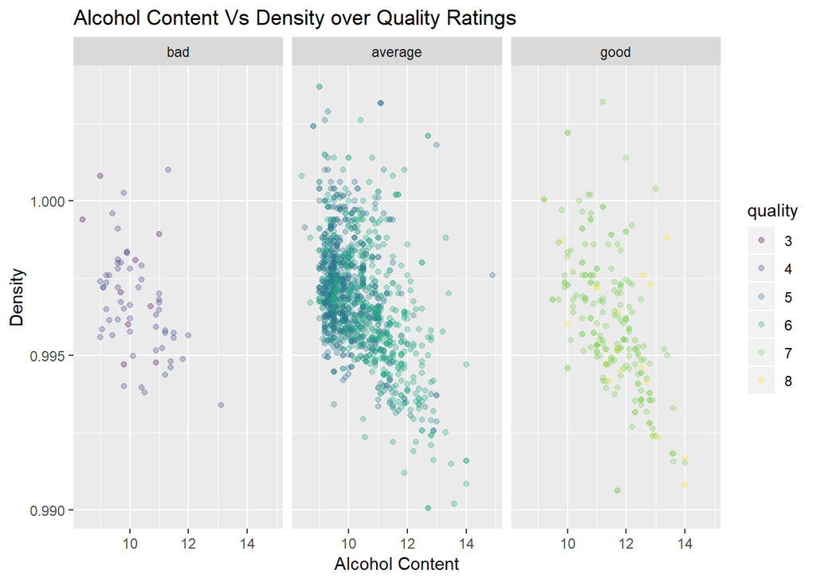

Again, as seen before we get to confirm that the density indeed has a negative relation with quality ratings. The lesser the number the better the ratings.

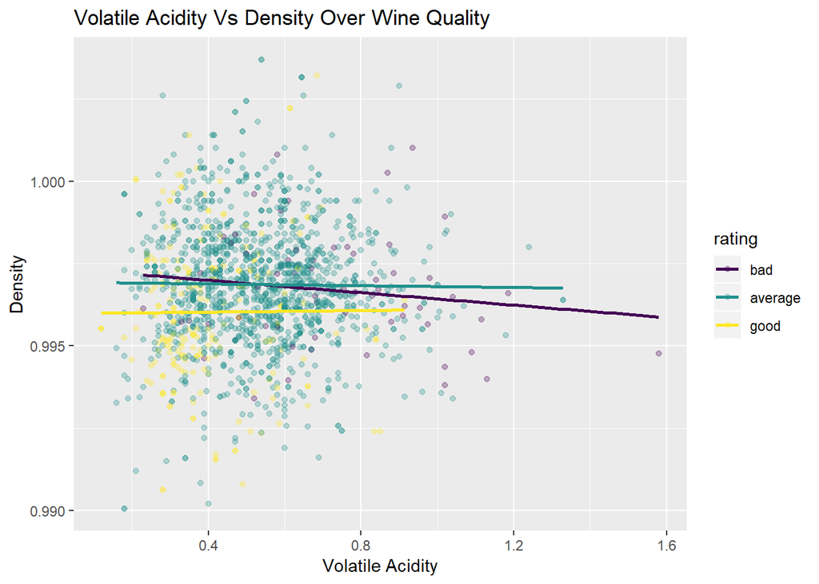

Two of the common factors that have been discussed are Volatility acid and Density. Rating is taken instead of quality to make the plot more easily understandable, with only three colors. We can see that there is a chunk of yellow near 0.995 in the density but this gradually decreases as we go up. We can see that there is a slight downward slope, similar to the one we saw in plot 2.

**Linear Model:**

Below I have created two linear model graphs.

The first one is a scatter plot between Alcohol Content and Density. I have include sequential in scale color brewer to have a progressive effect rather than the diverging or qualitative colors.

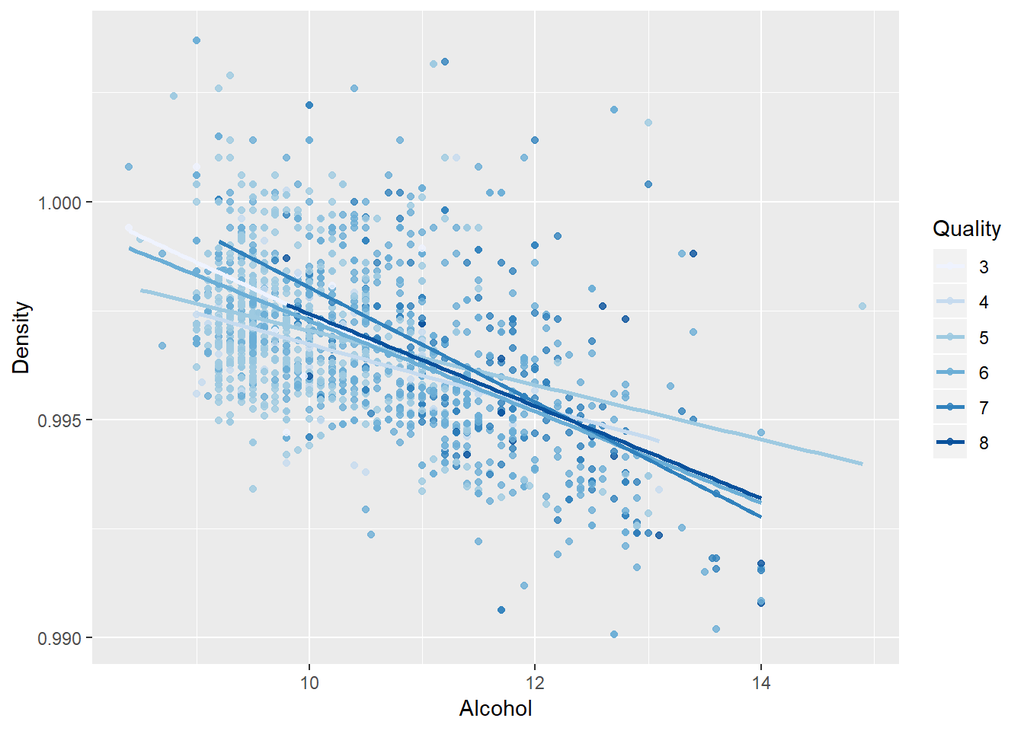

The second plot is between citric acid and volatile acidity. Even in this graph I have used sequential scale color brewer to give progressive effection for the lines in the graph.

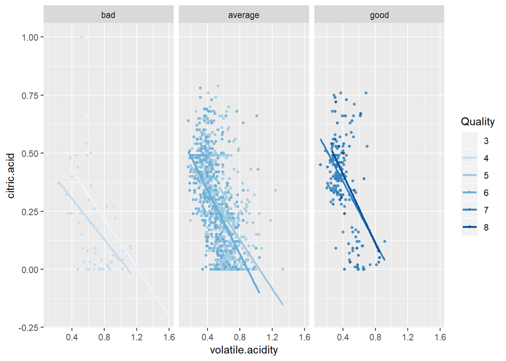

## Multivariant Analysis Section

**What were the observations made from the Multivariant graphs plotted?**

The citric acid content and volatile acid content seem to have a negative correlation. There is a lot of zero values in citric acid data but there is a chance that citric acid might not have been added in the wine.

**Where there any interesting or surprising interations between features?**

It was interesting to note that Lesser Chloride content produces better Wine Quality Ratings. There were quite a few number of outliers as well in chlorides. We can see a small chunk of points near 0.4 . Now this is interesting as we see many points in the average graph, maybe that is the reason for outliers. Maybe even more quality ratings falling in the good and bad quality ratings graph could have deviated from the 0.0 to 0.2 range. Now we see only a handful points. Maybe the number will increase with more ratings.

## Final Plots And Summary

### Plot 1:

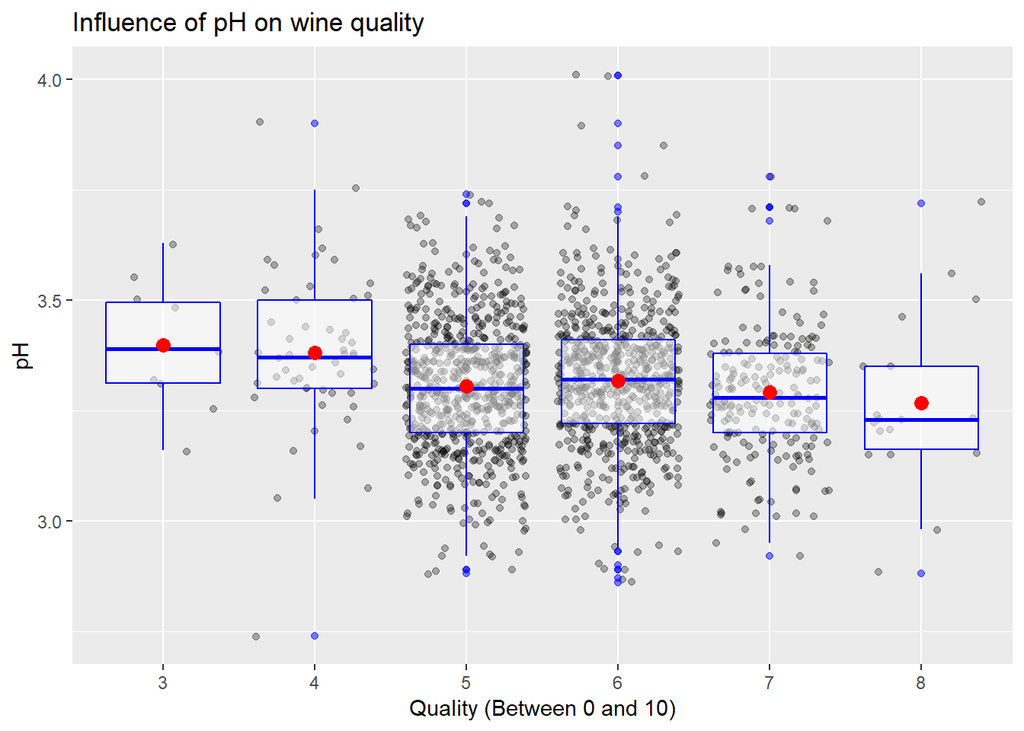

#### Description one:

I found that pH plays a major role in determining the quality of wine, so I plotted the above. As we see the plot, we can observe the there is a slight drop in pH as the quality increases. Also, we find that the median of the box plots coincides with the mean produced with the help of stat summary.

### Plot 2:

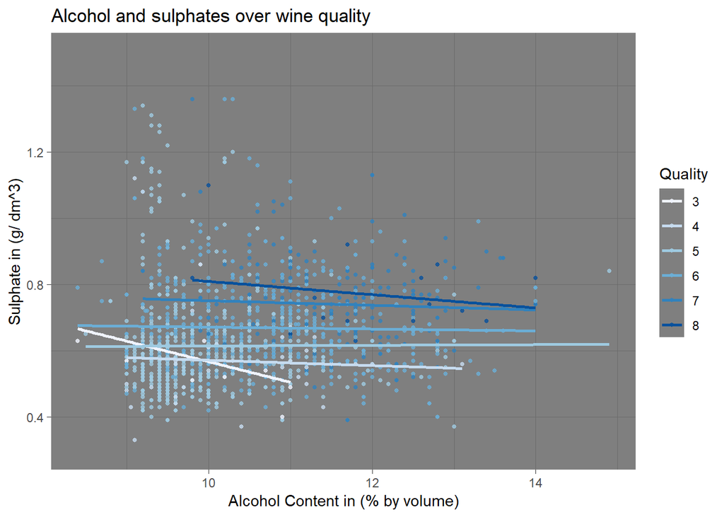

#### Description two:

It is now very obvious that the alcohol content and sulphates have a major impact on the quality of the wine. We can observe that the lines are getting darker as we go up the line. This indeed denotes that quality of wine has increased from bottom to top.

But the lines goes slightly downward. This suggests that the sulphates decrease with the increase in alcohol content.

### Plot 3:

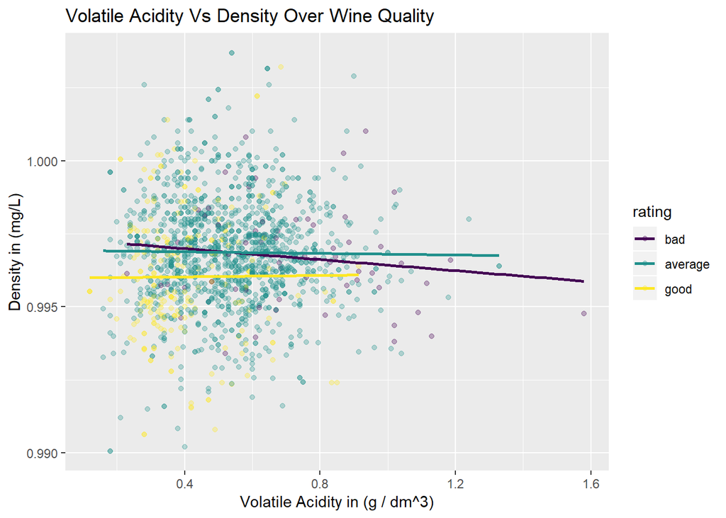

#### Description Three:

Two of the common factors that have been discussed are Volatility acid and Density. Rating is taken instead of quality to make the plot more easily understandable, with only three colors. We can see that there is a chunk of yellow near 0.995 in the density but this gradually decreases as we go up. We can see that there is a slight downward slope, similar to the one we saw in plot 2. Which makes sense since we saw lesser the pH better the Quality Ratings. This can also be taken as an indirect confirmation to the conclusion we had attained before.

## Reflection:

The Red Wine dataset contained about 1600 observations and 13 variables where given. From the beginning the main question has been to find the factors which influence the quality of the wine and how to improve the quality of wine.

As I started to analyse the data by plotting them, there is a small intuition as to what factors might influence the Quality Ratings. I took four factors that include pH, density, residual sugars and mainly alcohol content.

I initially stuggled to understand how there was no relation between the sugar content and Quality of wine. Common perception is that is an important factor. Sugar always influences food items. But as I progressed further, I was able to see more plots and get to the conclusion that it indeed was true.

As I progressed on my analysis I got a very good clarity and knowledge about my data. The plots gave better insight as to how the factors played out and influenced the Quality of the Red Wine Samples given. There were either positively skewed or normally distributed.

Coming to the limitation, it is found that most of the plots have only average values. The values are not evenly distributed. If there had been more observations, it would have been definetly possible.

Another drawback that I thought was the Quality Ratings. There was only one quality rating present. Even a movie will have a few critics. I feel there could have been more ratings given than just one. Maybe that would have given us various insights as to how different people feel about it and the different ways it could have been improved targetting a larger audience. Yes, it would have been more complex. But it would have been all the more, more interesting than just one Rating.